# Welcome to my Portfolio Project on WebScraping!

## In this project, I am going to analyze the Top 100 Covered Albums of All-Time. This project is definitely more personal to me as opposed to my other exercises. As an Amateur Musician, not only do I have a passion for music, but I most definitely love discovering covers of Songs/Albums where the artist provides his/her own twist to the original.

```python
#Make the necessary imports immediately to avoid errors.

import pandas as pd
import numpy as np
import seaborn as sns
import matplotlib.pyplot as plt
%matplotlib inline
import requests
from bs4 import BeautifulSoup
```

```python
#Here we are making an HTTP request to pull the HTML code from the URL we desire.

URL = "https://secondhandsongs.com/statistics?sort=covers&list=stats_release_covers"
r = requests.get(URL)
```

```python
soup = BeautifulSoup(r.content, "html5lib")
print(soup.prettify())
```

[output not shown]

[output cut: 2396 more lines]

[output not shown]

```python
#We would like to extract the <tr> tags belonging to the table, whose id = "vw"
rows = soup.select('#vw tr')
rows
```

[output not shown]

[output cut: 450 more lines]

[output not shown]

```python
frame = []
for row in rows:
    frame.append([td.text for td in row.select('td')])
    print([td.text for td in row.select('td')])
```

```
[]
['1', 'The Beatles [White Album]', 'The Beatles', '1634']
['2', 'Rubber Soul', 'The Beatles', '1497']
['3', 'Revolver', 'The Beatles', '1489']
['4', 'Abbey Road', 'The Beatles', '1468']
['5', 'Meet Me in St. Louis', 'Judy Garland with Georgie Stoll and His Orchestra', '1399']
['6', 'Silent Night, Hallowed Night', 'Haydn Quartet', '1378']
['7', 'The Christmas Song (Merry Christmas to You)', 'The King Cole Trio with String Choir', '1195']
['8', "Sgt. Pepper's Lonely Hearts Club Band", 'The Beatles', '1107']
['9', 'Help!', 'The Beatles', '1081']
['10', 'Were You Fooling', 'Richard Himber & His Orchestra', '996']
['11', 'Jingle Bells', 'Edison Male Quartette', '985']
['12', 'Body and Soul', 'Ambrose and His Orchestra', '955']
['13', 'God Rest Ye Merry, Gentlemen', 'Meister Glee Singers', '901']
['14', "A Hard Day's Night", 'The Beatles', '891']
['15', 'The First Nowell', 'Tally-Ho!', '839']
['16', "I'll Be Home for Christmas (If Only in My Dreams)", 'Bing Crosby with John Scott Trotter and His Orchestra', '830']
['17', "The Freewheelin' Bob Dylan", 'Bob Dylan', '801']
['18', 'Christmas with The Trapp Family Singers', 'The Trapp Family Singers', '794']
['19', "Somebody's Gotta Go", 'Cootie Williams and His Orchestra', '738']
['20', 'O Amor o Sorriso e a Flor', 'João Gilberto', '715']
['21', 'Let It Snow! Let It Snow! Let It Snow!', 'Vaughn Monroe and His Orchestra', '701']
['22', 'Tapestry', 'Carole King', '667']
['23', 'One Night in Havana', 'Hoagy Carmichael & His Pals', '626']
['24', 'Caravan', 'Barney Bigard and His Jazzopators', '620']
['25', 'Moon River', 'Henry Mancini, His Orchestra and Chorus', '619']
['26', 'Bridge over Troubled Water', 'Simon and Garfunkel', '606']
['27', 'Hesitating Blues', "Prince's Band", '599']
['28', 'St. Louis Woman - Original Broadway Cast', '', '595']
['29', 'Kind of Blue', 'Miles Davis', '579']
['30', 'Georgia (On My Mind)', 'Hoagy Carmichael and His Orchestra', '564']
['31', 'Orfeu Negro - Bande Originale du Film de Marcel Camus', '', '562']
['32', 'Songs in the Key of Life', 'Stevie Wonder', '541']
['33', 'Lover Man (Oh, Where Can You Be?)', 'Billie Holiday', '539']
['34', 'Giant Steps', 'John Coltrane', '533']
['35', 'Love Letters', 'Victor Young and His Concert Orchestra', '531']
['36', 'Sleigh Ride', 'Boston Pops Orchestra', '529']
['37', 'Willow Weep for Me', 'Ted Fiorito & His Orchestra', '527']
['38', 'Imagine', 'John Lennon', '526']
['39', 'Rudolph, the Red-Nosed Reindeer', 'Gene Autry and The Pinafores with Orchestral Accompaniment', '524']
```

[output cut: 46 more lines]

```
['86', 'The Bootleg Series Volumes 1-3', 'Bob Dylan', '386']
['87', 'God Bless the Child', 'Billie Holiday', '385']
['88', "Don't Blame Me", "Sarah Vaughan with George Treadwell's Orchestra", '381']
['89', 'The Joshua Tree', 'U2', '379']
['90', "Comme d'habitude", 'Claude François', '379']
['91', 'Carnegie Hall, November 13, 1948', 'Duke Ellington and His Orchestra', '378']
['92', 'Innervisions', 'Stevie Wonder', '377']
['93', 'Bye Bye Blackbird', "Sam Lanin's Dance Orchestra", '377']
['94', 'Bringing It All Back Home', 'Bob Dylan', '376']
['95', 'Secret Love', 'Doris Day', '375']
['96', "After You've Gone", 'Henry Burr & Albert Campbell', '374']
['97', 'Saturday Night Fever', '', '369']
['98', 'Blonde on Blonde', 'Bob Dylan', '368']
['99', 'Let It Be', 'The Beatles', '368']
['100', 'Dreamy Blues', 'The Jungle Band', '368']
```

## Another way we could've approached this scenario would be to use Pandas, which may have been easier. However, I'd prefer to use BeautifulSoup for purposes of this example.

```python
#table = pd.read_html('https://secondhandsongs.com/statistics?sort=covers&list=stats_release_covers')[0]
#print(table)
```

```python
df = pd.DataFrame(frame)
df.columns = ['Rank', 'Album', 'Artist', 'Count']
df.reset_index()
df.drop(0, inplace=True)
#Remove the zero index. Now everything is ranked 1-100
```

```python
df.tail(20)
```

|  | Rank | Album | Artist | Count |
| --- | --- | --- | --- | --- |
| 81 | 81 | The Wall | Pink Floyd | 398 |
| 82 | 82 | When You Wish Upon a Star - I've Got No Strings | Cliff Edwards with Victor Young and His Orches... | 398 |
| 83 | 83 | You'd Be So Nice to Come Home To | Dick Jurgens and His Orchestra | 394 |
| 84 | 84 | What the World Needs Now - Stan Getz Plays Bac... | Stan Getz | 391 |
| 85 | 85 | New Britain | The Original Sacred Harp Choir | 387 |
| 86 | 86 | The Bootleg Series Volumes 1-3 | Bob Dylan | 386 |
| 87 | 87 | God Bless the Child | Billie Holiday | 385 |
| 88 | 88 | Don't Blame Me | Sarah Vaughan with George Treadwell's Orchestra | 381 |
| 89 | 89 | The Joshua Tree | U2 | 379 |
| 90 | 90 | Comme d'habitude | Claude François | 379 |
| 91 | 91 | Carnegie Hall, November 13, 1948 | Duke Ellington and His Orchestra | 378 |
| 92 | 92 | Innervisions | Stevie Wonder | 377 |
| 93 | 93 | Bye Bye Blackbird | Sam Lanin's Dance Orchestra | 377 |
| 94 | 94 | Bringing It All Back Home | Bob Dylan | 376 |
| 95 | 95 | Secret Love | Doris Day | 375 |
| 96 | 96 | After You've Gone | Henry Burr & Albert Campbell | 374 |
| 97 | 97 | Saturday Night Fever |  | 369 |
| 98 | 98 | Blonde on Blonde | Bob Dylan | 368 |
| 99 | 99 | Let It Be | The Beatles | 368 |
| 100 | 100 | Dreamy Blues | The Jungle Band | 368 |

```python
#Create a copy of our DataFrame for some Data Visualization.
df1 = df[0:9]
df1 = df1.astype({'Count':int,'Rank':int}) #Converting the columns to be numeric, in order to be used for Plotting.
```

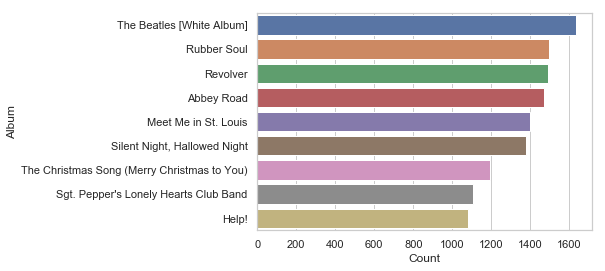

```python
sns.barplot(x= "Count",y="Album",data=df1)
```

```python
df['Count'] = df['Count'].astype(int)
```

```python
df['Count'].sum()
```

```
58925
```

```python
#The total Count of covers belonging to a Beatles Album:
Beatle = df.loc[df['Artist'] == 'The Beatles', 'Count'].sum()
Beatle
```

```
9977
```

```python
#The total Count of covers not belonging to a Beatles Album:
Not_beatle = Beatle = df.loc[df['Artist'] != 'The Beatles', 'Count'].sum()
Not_beatle
```

```
48948
```

```python
labels = ['Beatles', 'Non-Beatles']
sizes = [9977,48948]
colors = ['gold', 'yellowgreen']
explode = [0.1, 0]
```

## Using a simple Pie chart, we can see that the Beatles hold roughly 1/6 of the total number of Covers, in addition to holding the top 4 ranks. People clearly love this band!

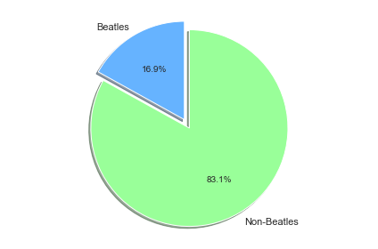

```python
plt.pie(sizes, explode=explode, labels=labels, autopct='%1.1f%%', colors = ['#66b3ff', '#99ff99'],
        shadow=True, startangle=90)
plt.tight_layout()
plt.axis('equal')
plt.show()
```

# This is the end of this project. We've conducted WebScraping & Data Manipulation/Visualization using various Python modules (BeautifulSoup, Numpy, Pandas, and Seaborn). Thanks for stopping by and please feel free to visit my Data Science blog: helloworldofdata.webnode.com